# Homework 2

Yixin Wang

## Linear Regression

For this lab, we will be working with a data set from the UCI (University of California, Irvine) Machine Learning repository ([see website here](http://archive.ics.uci.edu/ml/datasets/Abalone)). The full data set consists of $4,177$ observations of abalone in Tasmania. (Fun fact: Tasmania supplies about $25\%$ of the yearly world abalone harvest.)

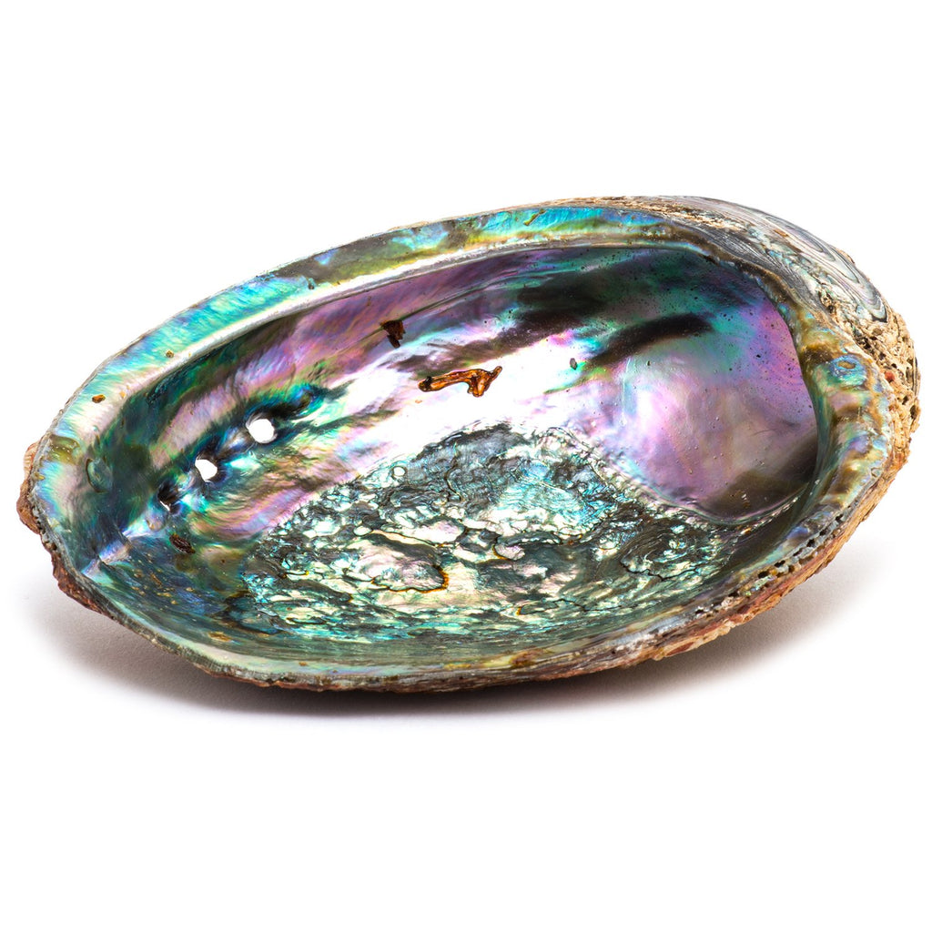

*Fig 1. Inside of an abalone shell.*

The age of an abalone is typically determined by cutting the shell open and counting the number of rings with a microscope. The purpose of this data set is to determine whether abalone age (**number of rings + 1.5**) can be accurately predicted using other, easier-to-obtain information about the abalone.

The full abalone data set is located in the `\data` subdirectory. Read it into *R* using `read_csv()`. Take a moment to read through the codebook (`abalone_codebook.txt`) and familiarize yourself with the variable definitions.

Make sure you load the `tidyverse` and `tidymodels`!

```r
library(tidyverse)
library(tidymodels)

abalone <- read_csv(file = "abalone.csv")
```

### Question 1

Your goal is to predict abalone age, which is calculated as the number of rings plus 1.5. Notice there currently is no `age` variable in the data set. Add `age` to the data set.

Assess and describe the distribution of `age`.

```r
abalone <- abalone %>%
  mutate(age = rings + 1.5)
```

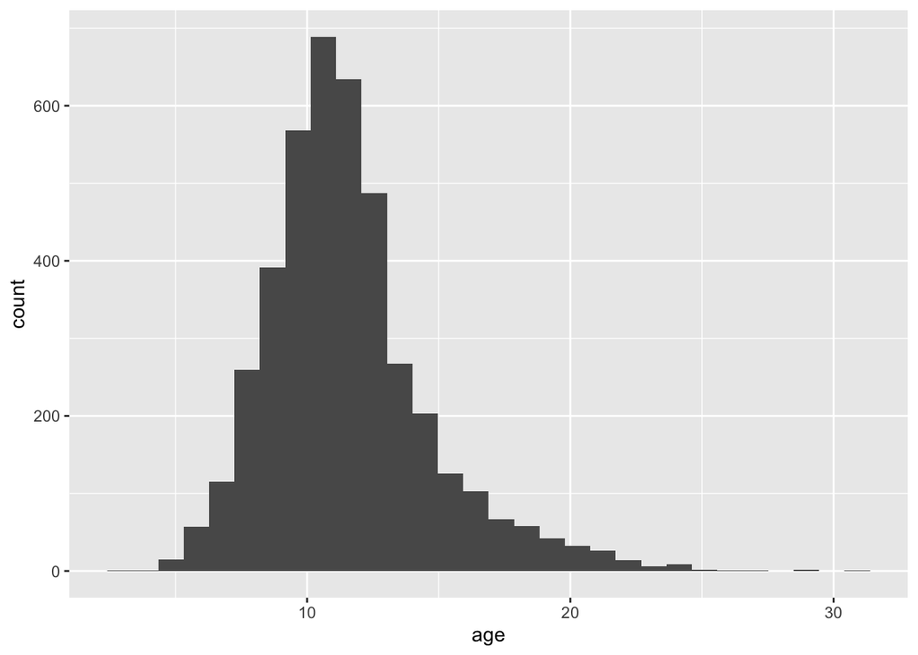

```r
abalone %>%
  ggplot(aes(x = age)) + geom_histogram()
```

Age appears to be normally distributed, even though there is a longer tail on the right side, which shows some degree of positive skew. Most abalone are between 7 and 13 years of age.

### Question 2

Split the abalone data into a training set and a testing set. Use stratified sampling. You should decide on appropriate percentages for splitting the data.

*Remember that you’ll need to set a seed at the beginning of the document to reproduce your results.*

```r
set.seed(3435)
abalone_split <- abalone %>% initial_split(strata = age, prop = 0.70)
abalone_train <- training(abalone_split)
abalone_test <- testing(abalone_split)
```

### Question 3

Using the **training** data, create a recipe predicting the outcome variable, `age`, with all other predictor variables. Note that you should not include `rings` to predict `age`. Explain why you shouldn’t use `rings` to predict `age`.

We should not use `rings` because age is dependent on rings. When rings included, the age will be explained by rings.

Steps for your recipe:

1. dummy code any categorical predictors
2. create interactions between
   - `type` and `shucked_weight`,
   - `longest_shell` and `diameter`,
   - `shucked_weight` and `shell_weight`
3. center all predictors, and
4. scale all predictors.

You’ll need to investigate the `tidymodels` documentation to find the appropriate step functions to use.

```r
abalone_recipe <- recipe(age ~ . , data = abalone_train) %>%
  step_rm(rings) %>%
  step_dummy(all_nominal_predictors()) %>%
  step_interact(terms = ~ starts_with("type"): shucked_weight +
                  longest_shell: diameter + shucked_weight: shell_weight) %>%
  step_normalize(all_predictors())
```

### Question 4

Create and store a linear regression object using the `"lm"` engine.

```r
lm_model <- linear_reg() %>%
  set_engine("lm")
```

### Question 5

Now:

1. set up an empty workflow,
2. add the model you created in Question 4, and
3. add the recipe that you created in Question 3.

```r
abalone_workflow <- workflow() %>%
  add_recipe(abalone_recipe) %>%
  add_model(lm_model)

abalone_fit <- fit(abalone_workflow, abalone_train)
```

### Question 6

Use your `fit()` object to predict the age of a hypothetical female abalone with longest_shell = 0.50, diameter = 0.10, height = 0.30, whole_weight = 4, shucked_weight = 1, viscera_weight = 2, shell_weight = 1.

```r
hypo_abalone <- data.frame(longest_shell = 0.50,
                           diameter = 0.10,
                           height = 0.30,
                           whole_weight = 4,
                           shucked_weight = 1,
                           viscera_weight = 2,
                           shell_weight = 1,
                           type = "F",
                           rings = 0)

predict(abalone_fit, hypo_abalone)
```

```
## # A tibble: 1 × 1
##   .pred
##   <dbl>
## 1  22.2
```

The age of this hypothetical female abalone is predicted about 22.2 years.

### Question 7

Now you want to assess your model’s performance. To do this, use the `yardstick` package:

1. Create a metric set that includes *R<sup>2</sup>*, RMSE (root mean squared error), and MAE (mean absolute error).
2. Use `predict()` and `bind_cols()` to create a tibble of your model’s predicted values from the **training data** along with the actual observed ages (these are needed to assess your model’s performance).
3. Finally, apply your metric set to the tibble, report the results, and interpret the *R<sup>2</sup>* value.

```r
multi_metric <- metric_set(rmse, rsq, mae)
abalone_predict <- predict(abalone_fit, abalone_train) %>%
  bind_cols(abalone_train %>% select(age))
multi_metric(abalone_predict, truth = age, estimate = .pred)
```

```
## # A tibble: 3 × 3
##   .metric .estimator .estimate
##   <chr>   <chr>          <dbl>
## 1 rmse    standard       2.11
## 2 rsq     standard       0.558
## 3 mae     standard       1.52
```

The $R^2$ value is small, which means that about 55% of variation in abalone age was explained by the model. The rmse and mae are both small, which suggest that this model could make good prediction on age.